# Assignment 6

Manuela Giansante

2023-04-21

## Exercise 4

```r
# necessary packages
library(fpp3)
library(fpp2)
library(dplyr)
library(ggplot2)
library(cowplot)
library(forecast)
library(tidyverse)
library(feasts)
library(reshape2)
library(lubridate)
library(kableExtra)
```

### 1. Plot the data and comment on its features. What can you observe? To what political , economical or social event/s it can be linked?

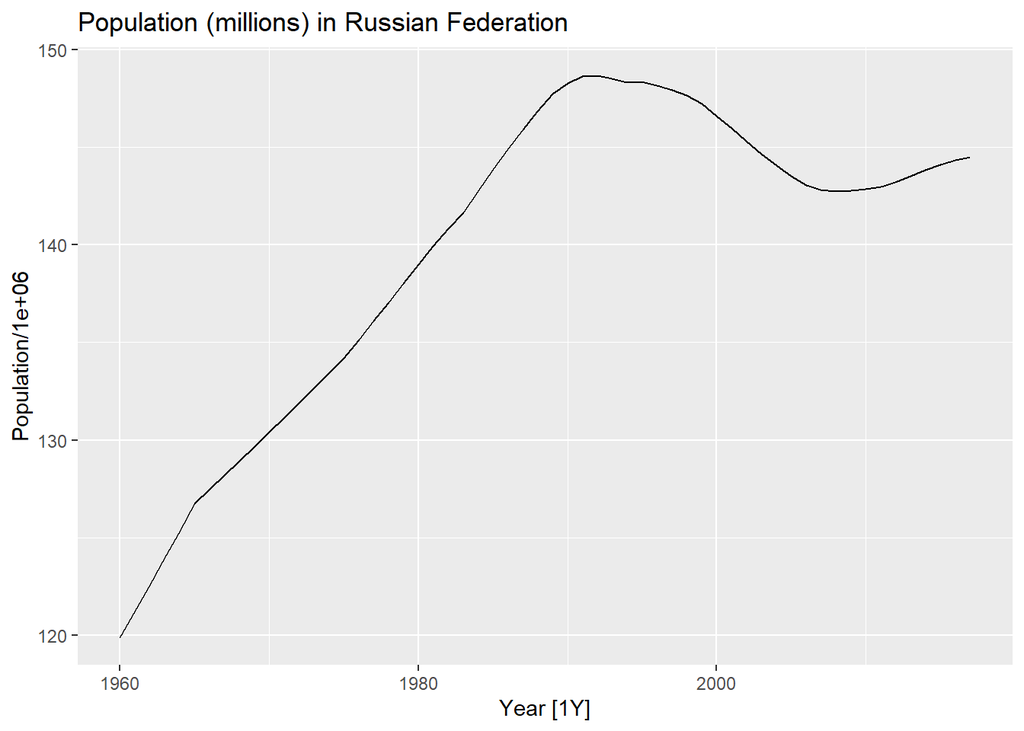

```r
global_economy |>
  filter(Country == "Russian Federation") |>
  autoplot(Population / 1e6) +
  labs(title = "Population (millions) in Russian Federation ")
```

The data is annual so we cannot observe seasonality, nor there seem to be any cyclical behaviours, which make sense given that the kind of data we are examining.

### 2. Fit a linear trend model and compare this to a piecewise linear trend model with knots at 1993 and 2008.

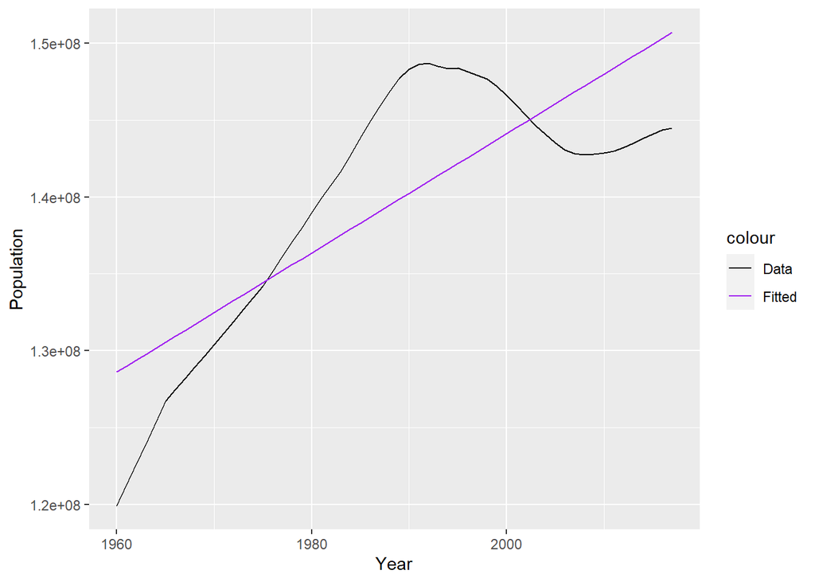

```r
ts_Russia<- global_economy %>%
  filter(Country == "Russian Federation") %>%
  select(Population)%>%
  index_by(Year)

# linear trend model
fit_lm<- ts_Russia %>%
  model(TSLM(Population ~ trend())) # we do not add seasonality

augment(fit_lm)%>%
  ggplot(aes(x = Year)) +
  geom_line(aes(y = Population, colour = "Data")) +
  geom_line(aes(y = .fitted, colour = "Fitted")) +
  scale_colour_manual(
    values = c(Data = "black", Fitted = "purple")
  )
```

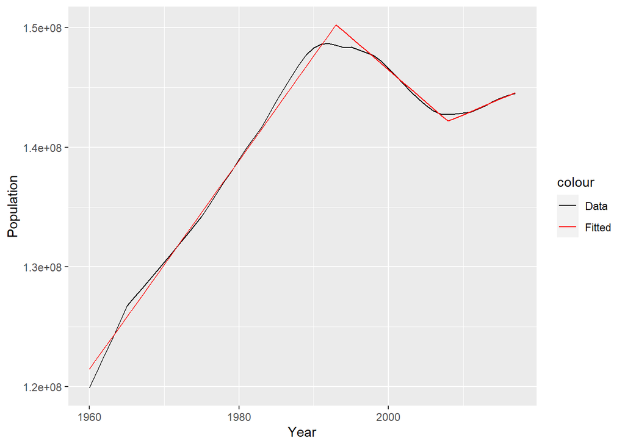

```r
#Piecewise regression model
fit_kn<- ts_Russia %>%
  model(piecewise= TSLM(Population ~ trend(knots=c(1993,2008))))

augment(fit_kn)%>%
  ggplot(aes(x = Year)) +
  geom_line(aes(y = Population, colour = "Data")) +
  geom_line(aes(y = .fitted, colour = "Fitted")) +
  scale_colour_manual(
    values = c(Data = "black", Fitted = "red")
  )
```

#### Comparison

The two models do have linear regression assumptions, but we need to take note that where the model changes slope, the structure of the error might change as well. For the linear regression model we assume that the errors in the model: - have mean zero and are homoskedastic (have constant variance, so to generate prediction intervals); - they are not autocorrelated (nor correlated to the selected predictor variables), so the past errors hold no information about the future ones; - they are normally distributed, meaning they are symmetric

We check assumptions for the **linear model**:

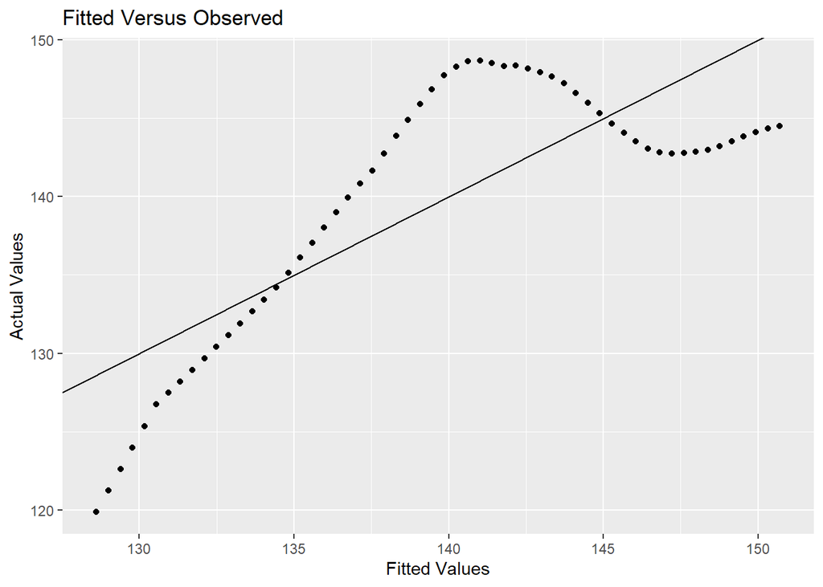

```r
augment(fit_lm) %>%
  ggplot(aes(x = .fitted / 1e6, y = Population / 1e6 )) +
  geom_point() +
  labs(
    y = "Actual Values",
    x = "Fitted Values",
    title = "Fitted Versus Observed"
  ) + geom_abline(intercept = 0, slope = 1)
```

The linear model does not fit the data well, given that the observations show clear pattern, this was predictable.

```r
report(fit_lm)
```

```
## Series: Population
## Model: TSLM
##
## Residuals:
##      Min       1Q   Median       3Q      Max
## -8715433 -4359379  -617162  4284380  8053401
##
## Coefficients:
##              Estimate Std. Error t value Pr(>|t|)
## (Intercept) 128224895    1313975   97.59  < 2e-16 ***
## trend()        387539      38739   10.00 4.51e-14 ***
## ---
## Signif. codes:  0 '***' 0.001 '**' 0.01 '*' 0.05 '.' 0.1 ' ' 1
##
## Residual standard error: 4939000 on 56 degrees of freedom
## Multiple R-squared: 0.6412,  Adjusted R-squared: 0.6348
## F-statistic: 100.1 on 1 and 56 DF, p-value: 4.5074e-14
```

Moreover the R^2 of the model is quite poor, in this given we only regress on trend(), R^2 and adjusted R^2 are not very different. We can see this statistic as generalized version of the correlation between y and the predictors, which in our case is the trend of the data. We can see that the model does a poor job.

```r
# Sample Mean
mean(ts_Russia$Population / 1e6)
```

```
## [1] 139.6573
```

```r
4939000/ 1e6
```

```
## [1] 4.939
```

We computed the sample mean to compare it with the Standard error which is the size of the error that the model produces on average.

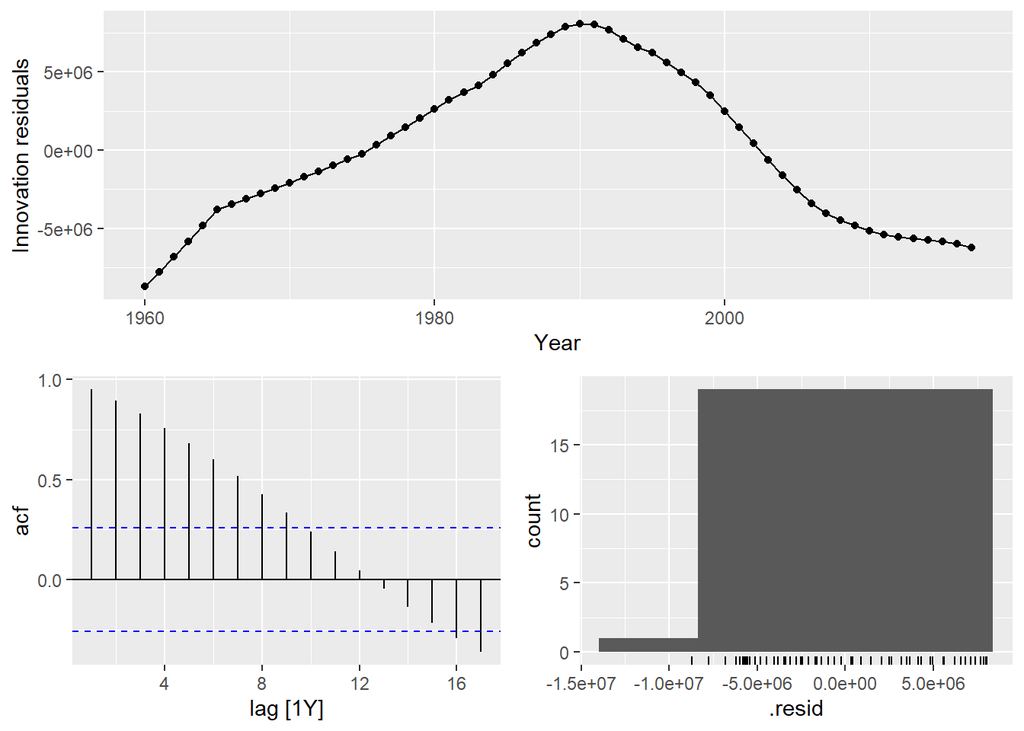

```r
gg_tsresiduals(fit_lm)
```

The linear regression model does not seem to be a good fit, the errors are not independent (autocorrelation is still present) nor normally distributed (the histogram is not symmetric). We cannot assume that the resdiuals are stationary nor reduced to white noise from fitting a linear regression.

We check the **piecewise linear model**:

```r
report(fit_kn)
```

```
## Series: Population
## Model: TSLM
##
## Residuals:
##      Min       1Q   Median       3Q      Max
## -1720015  -209739    29784   298520   974825
##
## Coefficients:
##                                       Estimate Std. Error t value Pr(>|t|)
## (Intercept)                          120606709     195119  618.12   <2e-16 ***
## trend(knots = c(1993, 2008))trend       871568       8943   97.45   <2e-16 ***
## trend(knots = c(1993, 2008))trend_34  -1408169      26525  -53.09   <2e-16 ***
## trend(knots = c(1993, 2008))trend_49    802930      63112   12.72   <2e-16 ***
## ---
## Signif. codes:  0 '***' 0.001 '**' 0.01 '*' 0.05 '.' 0.1 ' ' 1
##
## Residual standard error: 577900 on 54 degrees of freedom
## Multiple R-squared: 0.9953,  Adjusted R-squared: 0.995
## F-statistic:  3782 on 3 and 54 DF, p-value: < 2.22e-16
```

Let’s compare standard errors

```r
# Sample Mean
mean(ts_Russia$Population / 1e6)
```

```
## [1] 139.6573
```

```r
577900/ 1e6
```

```
## [1] 0.5779
```

The average size of model generated errors is much smaller for the piecewise regression models.The R^2 has increased a lot and actually signals a quite good model.

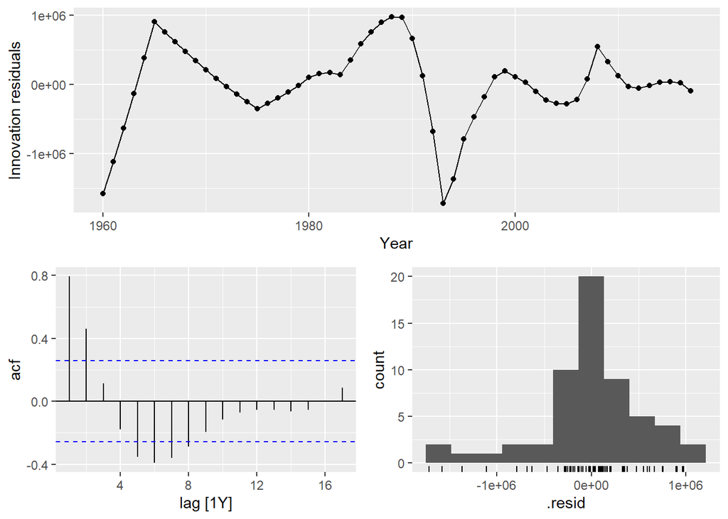

```r
gg_tsresiduals(fit_kn)
```

The model is not yet “optimal” given the autocorrelation and asymmetry of the residuals, but for sure it is a stepforward, using more knots and place them differently could be a way to go in order to improve the model.

### 3. Generate forecasts from these two models for the five years after the end of the data, and comment on the results.

Given we are regression only on trend(), generating an ex-post forecast is not an option.

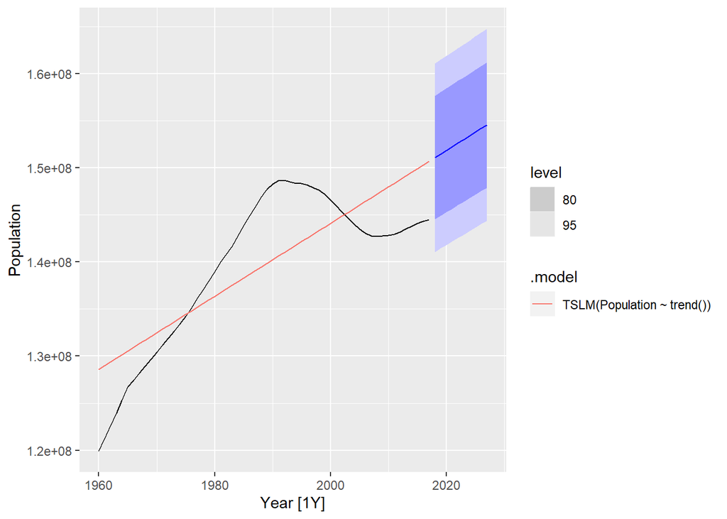

```r
#Forecast for the linear model
fc_lm<- fit_lm %>% fabletools::forecast(h=10)

ts_Russia %>%
  autoplot(Population) +
  geom_line(data = fitted(fit_lm),
            aes(y = .fitted, colour = .model)) +
  autolayer(fc_lm)
```

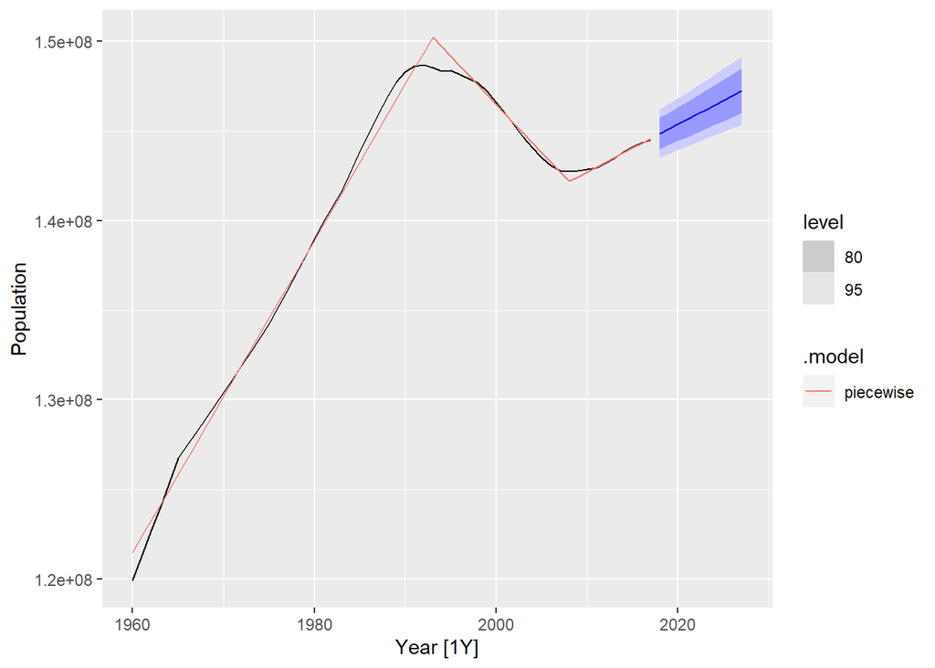

```r
#Forecast for the piecewise model
fc_kn<- fit_kn %>% fabletools::forecast(h=10)

ts_Russia %>%
  autoplot(Population) +
  geom_line(data = fitted(fit_kn),
            aes(y = .fitted, colour = .model)) +
  autolayer(fc_kn)
```

Because of the better fit of the second model, the confidence interval is smaller for the second fitted function prediction.

Another option could be to regress Population on other economic indicators, which for historical reasons have a lot of missing data, but we know might have actually influenced the evolution of the population in the country.

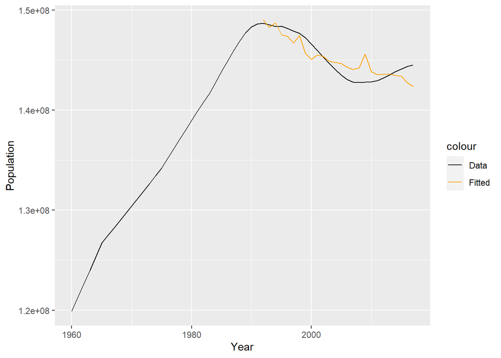

```r
ts_Russia2<- global_economy %>%
  filter(Country == "Russian Federation") %>%
  select(Population, Growth, CPI)%>%
  index_by(Year)

fit_lm2<- ts_Russia2 %>%
  model(TSLM(Population ~ Growth + CPI)) # we do not add seasonality

augment(fit_lm2)%>%
  ggplot(aes(x = Year)) +
  geom_line(aes(y = Population, colour = "Data")) +
  geom_line(aes(y = .fitted, colour = "Fitted")) +
  scale_colour_manual(
    values = c(Data = "black", Fitted = "orange")
  )
```

```r
report(fit_lm2)
```

```
## Series: Population
## Model: TSLM
##
## Residuals:
##      Min       1Q   Median       3Q      Max
## -2810403  -663282   -87736   773801  2132637
##
## Coefficients:
##              Estimate Std. Error t value Pr(>|t|)
## (Intercept) 147168921     379077 388.229  < 2e-16 ***
## Growth        -126910      37041  -3.426  0.00231 **
## CPI            -27415       4647  -5.899 5.17e-06 ***
## ---
## Signif. codes:  0 '***' 0.001 '**' 0.01 '*' 0.05 '.' 0.1 ' ' 1
##
## Residual standard error: 1188000 on 23 degrees of freedom
## Multiple R-squared: 0.7302,  Adjusted R-squared: 0.7067
## F-statistic: 31.12 on 2 and 23 DF, p-value: 2.8688e-07
```

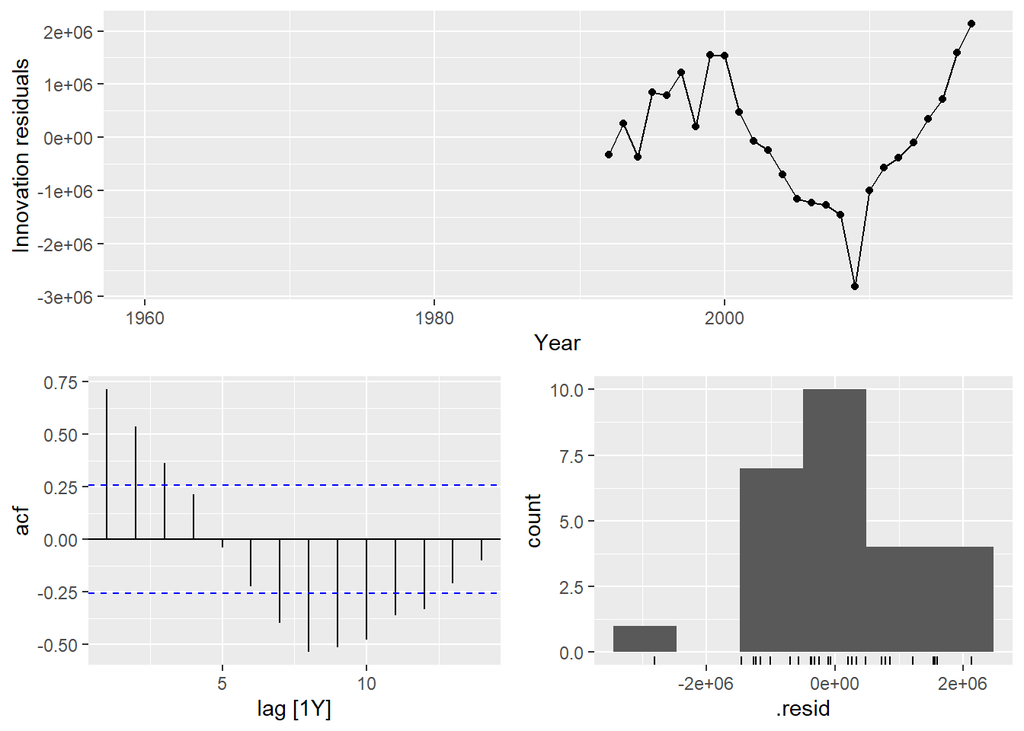

```r
gg_tsresiduals(fit_lm2)
```

### 4. Repeat analysis for Spain. Adapt knots in question 2 accordingly to the data.

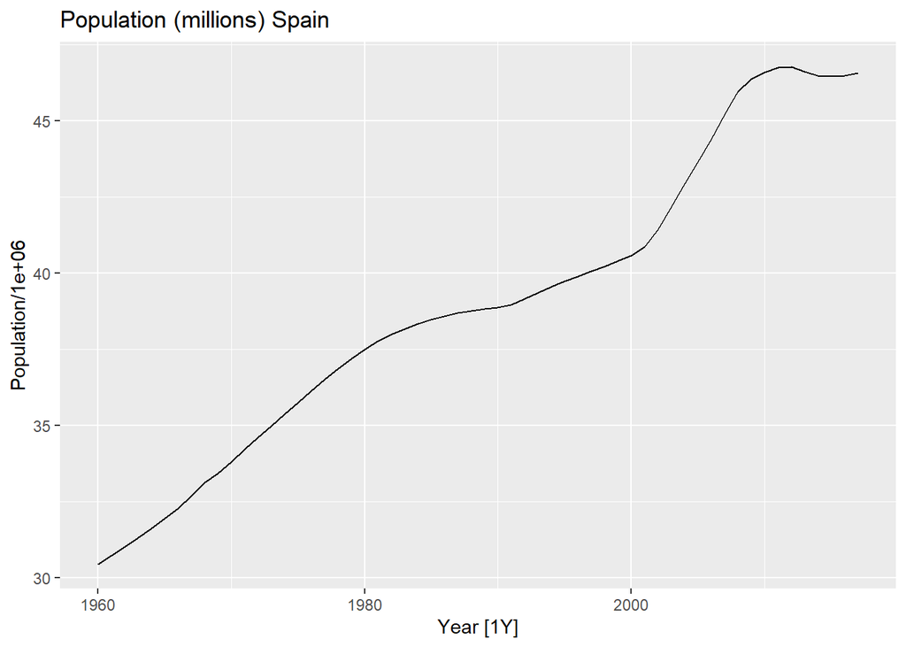

```r
global_economy |>
  filter(Country == "Spain") |>
  autoplot(Population / 1e6) +
  labs(title = "Population (millions) Spain")
```

The data all in all shows constant growth over the decades, in the most recent decade the level has stabilised a lot. This can be easily attributed to the change of life styles after the 2008 and 2011-2012 crises. In 1960 the population level was around 30 million people, around the start of the 80s the inclination of the evolution of the level slowed down.In the 80s and 90s Spain implemented policies intended to increase immigration which definitely impacted the population level. The slope changes becoming more steep at the start of the new century. Again, if available population average age would be a good indicator that we could consult.

#### Fitting the two models:

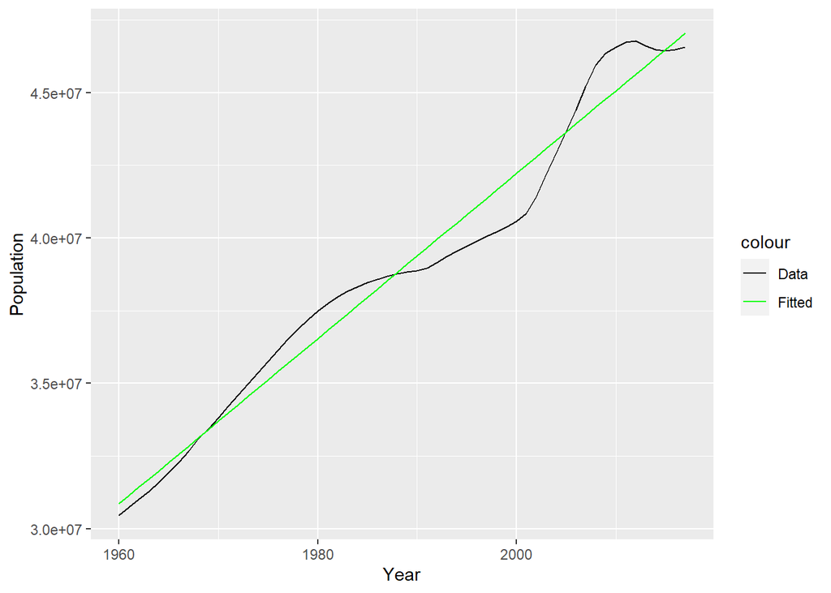

```r
ts_Spain<- global_economy %>%
  filter(Country == "Spain") %>%
  select(Population)%>%
  index_by(Year)

fit_lm_sp<- ts_Spain %>%
  model(TSLM(Population ~ trend())) # we do not add seasonality

augment(fit_lm_sp)%>%
  ggplot(aes(x = Year)) +
  geom_line(aes(y = Population, colour = "Data")) +
  geom_line(aes(y = .fitted, colour = "Fitted")) +
  scale_colour_manual(
    values = c(Data = "black", Fitted = "green")
  )
```

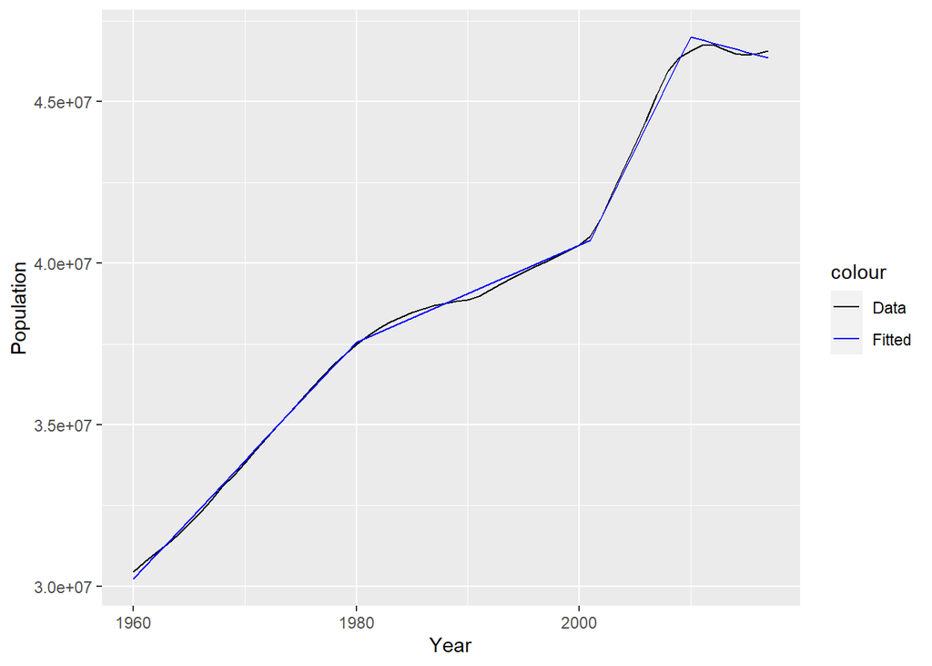

```r
fit_kn_sp<- ts_Spain %>%
  model(piecewise= TSLM(Population ~ trend(knots=c(1980,2001,2010))))

augment(fit_kn_sp)%>%
  ggplot(aes(x = Year)) +
  geom_line(aes(y = Population, colour = "Data")) +
  geom_line(aes(y = .fitted, colour = "Fitted")) +
  scale_colour_manual(
    values = c(Data = "black", Fitted = "blue")
  )
```

The knots are placed so that the fitted function follws the data more closely.

#### Comparison

```r
# Linear Model
report(fit_lm_sp)
```

```
## Series: Population
## Model: TSLM
##
## Residuals:
##      Min       1Q   Median       3Q      Max
## -1658262  -470754    -6876   689737  1581911
##
## Coefficients:
##             Estimate Std. Error t value Pr(>|t|)
## (Intercept) 30578781     229037  133.51   <2e-16 ***
## trend()       284045       6752   42.06   <2e-16 ***
## ---
## Signif. codes:  0 '***' 0.001 '**' 0.01 '*' 0.05 '.' 0.1 ' ' 1
##
## Residual standard error: 860900 on 56 degrees of freedom
## Multiple R-squared: 0.9693,  Adjusted R-squared: 0.9688
## F-statistic:  1770 on 1 and 56 DF, p-value: < 2.22e-16
```

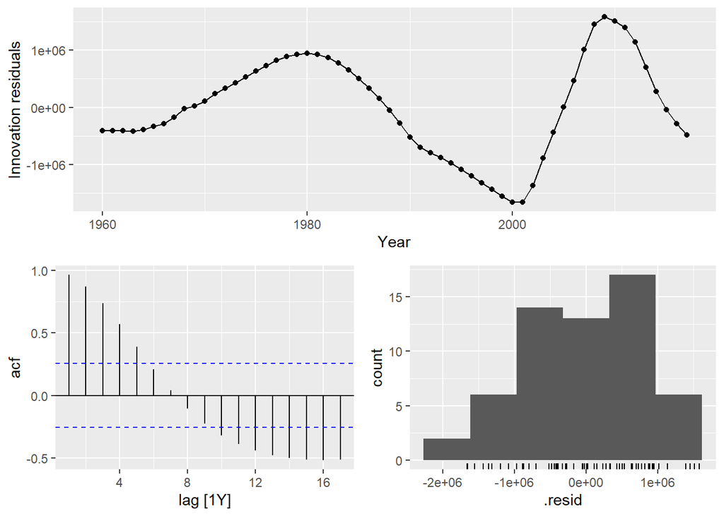

```r
gg_tsresiduals(fit_lm_sp)
```

For the Spain time series the simple linear regression is more fitting, the R^2 is acceptable.But is not a very good model regardless, the residual still have a lot autocorrelations, they form a clear patter when they are plotted on their own, nor they seem to be normally distributed. The model is unable to reduce the residuals to white noise.

```r
# Piece wise model
report(fit_kn_sp)
```

```
## Series: Population
## Model: TSLM
##
## Residuals:
##     Min      1Q  Median      3Q     Max
## -426492  -85652   -2998   72262  347370
##
## Coefficients:
##                                            Estimate Std. Error t value Pr(>|t|)
## (Intercept)                                29855270      61240  487.51   <2e-16
## trend(knots = c(1980, 2001, 2010))trend      366933       4184   87.69   <2e-16
## trend(knots = c(1980, 2001, 2010))trend_21  -216572       6981  -31.02   <2e-16
## trend(knots = c(1980, 2001, 2010))trend_42   547966      12612   43.45   <2e-16
## trend(knots = c(1980, 2001, 2010))trend_51  -790396      25695  -30.76   <2e-16
##
## (Intercept)                                ***
## trend(knots = c(1980, 2001, 2010))trend    ***
## trend(knots = c(1980, 2001, 2010))trend_21 ***
## trend(knots = c(1980, 2001, 2010))trend_42 ***
## trend(knots = c(1980, 2001, 2010))trend_51 ***
## ---
## Signif. codes:  0 '***' 0.001 '**' 0.01 '*' 0.05 '.' 0.1 ' ' 1
##
## Residual standard error: 144300 on 53 degrees of freedom
## Multiple R-squared: 0.9992,  Adjusted R-squared: 0.9991
## F-statistic: 1.623e+04 on 4 and 53 DF, p-value: < 2.22e-16
```

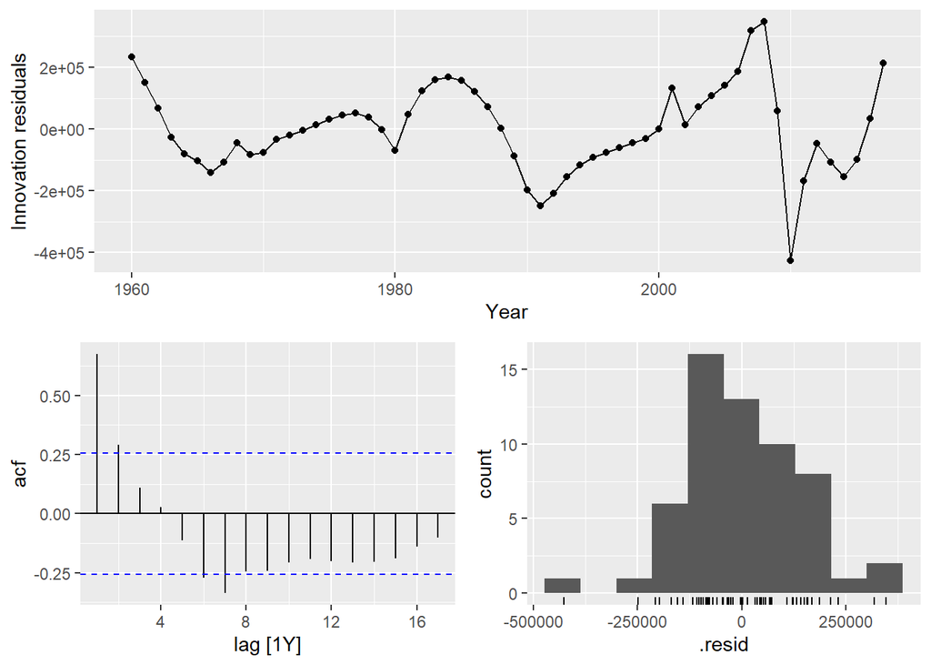

```r
gg_tsresiduals(fit_kn_sp)
```

The R^2 is higher than the one displayed by the former model. Autocorrelation is much lower, there is some in lag 1 and lag 2, meaning that the error of the estimated data-point corresponding to the year y is correlated with the error of the two previous years. TH residuals appear more centred around 0, but definitely no symmetric. The residuals appear more random in the scatter plot but not so much. Adding more knots might be a recommended.

#### Forecast

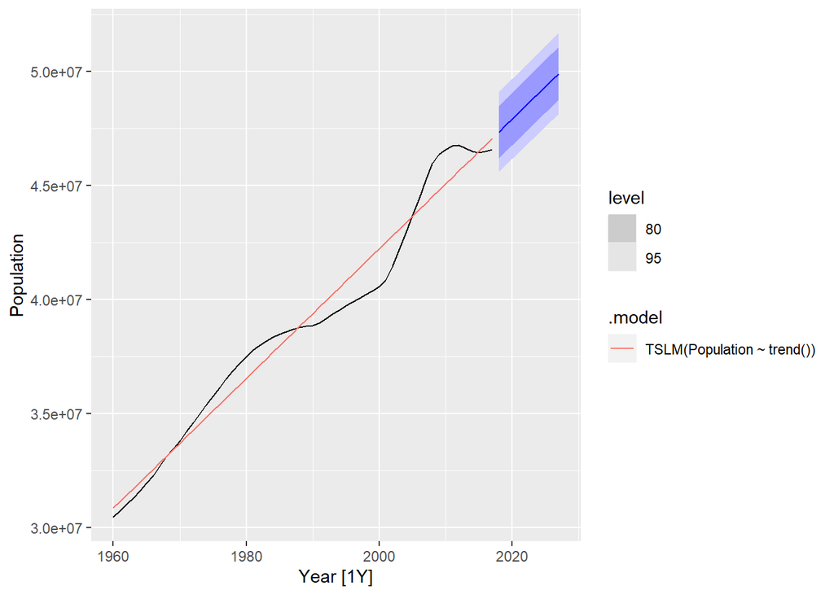

```r
fc_lm_sp<- fit_lm_sp %>% fabletools::forecast(h=10)

ts_Spain %>%
  autoplot(Population) +
  geom_line(data = fitted(fit_lm_sp),
            aes(y = .fitted, colour = .model)) +
  autolayer(fc_lm_sp)
```

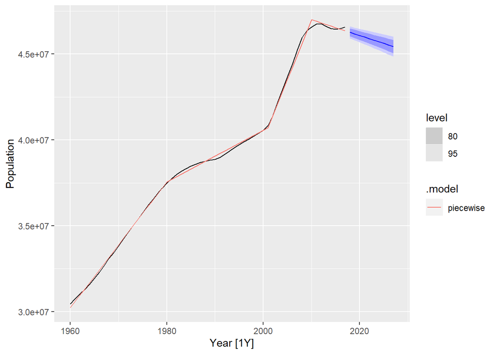

```r
fc_kn_sp<- fit_kn_sp %>% fabletools::forecast(h=10)

ts_Spain %>%
  autoplot(Population) +
  geom_line(data = fitted(fit_kn_sp),
            aes(y = .fitted, colour = .model)) +
  autolayer(fc_kn_sp)
```

Here as well the piecewise regression has smaller intervals around the point forecast, less uncertainty on the beta parameter.The prediction has Student’s t distribution. The prediction interval is $[x*\hat{b}\pm t_{T-(p+1);1-a/2}s\sqrt{(1+x*(X^T X)^{-1}x*^T)}]$. The amplitude of the CIs can be inflated by the term $sx*(X^T X)^{-1}x*^T$ which as mentioned above is the uncertainty on the coefficient. As the number of observations ($T$) grows the t distribution will converge to normal and the term will move towards 0.